# Project 2 FINAL

## Introduction

#### Scientific Question

- How does the gene FKBP5 in animals contribute to further studies of stress response and cellular processes in the human body?

#### Background of Gene FKBP5

- FKBP5, also known as FK506 binding protein 5, is an important modulator of stress response. The gene FKBP5 acts as a co-chaperone that modulates the glucocorticoid receptor activity in response to stressors and other cellular processes in the brain and periphery (Zannas et al. 2016)
- FKBP5 is a strong inhibitor of the glucocorticoid receptor (GR)
- The upregulation of FKBP5 will activate GR and its sensitivity, which increases stress hormone system and regulation. Furthermore, effiency of the negative feedback of the stress hormone axis decreases in health control (Binder 20090

#### Scientific Hypothesis:

- If the gene FKBP5 is associated with depression and stress in both humans and animals, and this gene in animals are genetic simialr to humans, then researchers can use analyzed data to further study stress response and cellular processes in humans and find more information on how the regulation of FKBP5 impact their depressive diseases and disorders.

#### Description of Analyses and Data

- In order to answer the scientific question, we must compare the sequence identity and genetic similarities between human and animals. The animals of interests are rats, monkeys, and sloth.
- Rats was selected to be the animal of interest because many scientists and their studies believe that rats and mice are anatomically, physiologically, and genetically similary to humans. It would be interesting to compare whether or not the gene FKBP5 in rats are similar to humans than other animals (Bryda 2013).
- Because the gene FKBP5 is related to stress response and cellular processes, we want to see which animals are the most stressed out, and we found that mid-ranking monkeys may be stressed out more than humans (Nuwer 2013). Therefore, we wanted to collect datas on their FKBP5 and see whether their FKBP5 gene is more closely related to the human FKBP5 gene than other animals.
- The last animal of interest is the sloth. As we all know, sloths are extremely slow with low metabolic rate. We wanted to see if the FKBP5 gene in sloths is similar to human.
- Pairwise Sequence Alignment will be used in this research to compare genetic similarity in the gene FKBP5 for both human and animals.
- Phylogenetic Clustering will be used to create and illustrate a phylogenetic tree to display the relations between the FKBP5 gene in human vs the animals of interest. Results will show which animals, out of three, are most similar to humans.

Tools

- NCBI: National Center for Biotechnology Information

NCBI Nucleotide Accessions

- Human (Homo sapiens): NM_001145775.3
- Rat (Rattus norvegicus): NM_001012174.2
- Monkey (Saimiri boliviensis): NM_001280014.1
- Sloth (Choloepus didactylus): XM_037842905

Source:

- FKBP5: https://pubmed.ncbi.nlm.nih.gov/19560279/
- Rat: https://www.ncbi.nlm.nih.gov/pmc/articles/PMC3987984/
- Monkey: https://www.smithsonianmag.com/smart-news/whether-monkey-or-human-middle-managers-are-the-most-stressed-out-15191138/

## Loading in Packages

Numpy: also know as Numerical Python, is a Python library used for working with different arrays. It has multiple functions that contains matrix data structures and mutlti-dimensional arrays. https://www.w3schools.com/python/numpy/numpy_intro.asp

Pandas: is a Python library that can be used for data science, data analysis and machine learning tasks. Simiarly to many computer programs, Pandas is useful for computing data, read dataframes, and perform further analysis. Pandas make it easier to work with tabular data, which can perform all partw of analysis from collection of datas. https://github.com/stefmolin/pandas-workshop#:~:text=Pandas%20makes%20it%20possible%20to,manipulation%20through%20aggregation%20and%20visualization.

Align/AlignIO: is a Python package for multiple sequence alignment input/output interface. It is used with Bio to perform sequence alignments within collected datas. https://biopython.org/wiki/AlignIO#:~:text=AlignIO%20%2C%20a%20new%20multiple%20sequence,in%20addition%20to%20this%20page.

SeqIO: is a Python package that provides a simple unique interface to input and output assorted sequence file formats (including multiple sequence alignments that will be used in this research). This will only deal with sequences as SeqRecord objects. https://biopython.org/wiki/SeqIO#:~:text=SeqIO%20provides%20a%20simple%20uniform,alignment%20files%20as%20Alignment%20objects.

Bio.Pairwise2: is a Python module/package that use dynamic programming algorithms to provide functions in order to get global or local alignments between two sequences. https://biopython.org/docs/1.76/api/Bio.pairwise2.html#:~:text=Bio.-,pairwise2%20module,all%20characters%20in%20two%20sequences.

Biopython: is a Python package that can be used to work with biological data. It is a collection of python modules that provide functions to compute molecular biology, including DNA, RNA, and protein sequence operations. https://www.tutorialspoint.com/biopython/biopython_introduction.htm

Bio.Phylo: is a Python package consisted with libraries and tools to analyze/parsing files and creating visualizing trees. It can be used to create phylogenetic clusering/tree to display the genetic similarity and evolutionary relationship within groups of organisms. https://bmcbioinformatics.biomedcentral.com/articles/10.1186/1471-2105-13-209

```python
import numpy as np
import pandas as pd
import matplotlib.pyplot as plt

from Bio import SeqIO
from Bio import Align
from Bio import AlignIO
from Bio import pairwise2

from Bio.Seq import Seq
from Bio.pairwise2 import format_alignment
from Bio.PDB import *

from Bio import Phylo, AlignIO
```

## Performing Bioinformatics Analysis

The tool that was used to collect datas (sequencees) was NCBI. Nucleotide sequences (of human and animals) were downloaded from NBCI and uploaded into Jupyter Notebook as fasta files. A fasta file is text file compiled of either protein or nucleotide sequences.

Source

- How to parse a fasta file in python https://www.biostars.org/p/710/
- Alignment https://biopython-tutorial.readthedocs.io/en/latest/notebooks/06%20-%20Multiple%20Sequence%20Alignment%20objects.html

```python
#Defining files and align
human_alignment = AlignIO.read("human_sequence.fasta", "fasta")
rat_alignment = AlignIO.read("rat_sequence.fasta", "fasta")
monkey_alignment = AlignIO.read("monkey_sequence.fasta", "fasta")
sloth_alignment = AlignIO.read("sloth_sequence.fasta", "fasta")

#Alignment of each sequence
print(human_alignment)
print(rat_alignment)
print(monkey_alignment)
print(sloth_alignment)

#Defining each file and converting nucleotide sequences into seq
FKBP5_human = next(SeqIO.parse("human_sequence.fasta", "fasta")).seq
FKBP5_rat = next(SeqIO.parse("rat_sequence.fasta", "fasta")).seq
FKBP5_monkey = next(SeqIO.parse("monkey_sequence.fasta", "fasta")).seq
FKBP5_sloth = next(SeqIO.parse("sloth_sequence.fasta", "fasta")).seq

#Length of each sequence
print(len(FKBP5_human))
print(len(FKBP5_rat))
print(len(FKBP5_monkey))
print(len(FKBP5_sloth))
```

```
Alignment with 1 rows and 3935 columns
AGAACAAACTCCTACCTCTGTTTGCAACTAAGAGTTACATCCCC...TGA NM_001145775.3
Alignment with 1 rows and 3478 columns
CGGCGGCCTGCTGGGCGGGCTGAGCGGCGCGCGCGGCGGAGAGA...TAA NM_001012174.2
Alignment with 1 rows and 1448 columns
GGTTCTCTACTTAAAAGACAATGACTACTGATGAAGGTGCCAAG...GGG NM_001280014.1
Alignment with 1 rows and 4076 columns
GACCCTATGGAAGGCGGGTCCTGCGGCCGGCGGGAGCGGGACGG...TCA XM_037842905.1
3935
3478
1448
4076
```

#### Pairwise Alignment

- also known as Pairwise Sequence Alignment is used to compare two sequences.
- In this research, pairwise alignment was performed to compare the gene FKBP5 sequence in human and different animals of interest.

Source: Pairwise Alignment Module https://biopython.org/docs/1.75/api/Bio.pairwise2.html

```python
#Defining the function to do pairwise alignment
def align(sequence1, sequence2):
    alignment_sequence1_sequence2 = pairwise2.align.globalxx(sequence1, sequence2)
    print(format_alignment(*alignment_sequence1_sequence2[0]))
```

```python
#Alignment of Human and Rat
align(FKBP5_human, FKBP5_rat)
```

```
AGAACAAACTCCTACCTCTGTTTGCAACTAAGAGTTACATCCCCCATGCCAAGACCTTCC…-AGGTTCT-CTACTTA-AAAG-ACAATGACTACTGATGAAGGTGCCA--AG-AACAATGAAGAAAGC-CCCA-CAGCCACT-GTTGC-T-GAGCAGGGAGAG-GATATTAC-CTC-C-AAAAAAGAC-AGG-GGAGTATTAAAGATTGTCAAAAGAGTGGGGAA-TG-GTGAGGAA-ACGCCG-A-TGATTGGA-GACAAAG-TTTATGTCCAT-TACAAAGGAA-AA-TTGTCA-AAT…
                           |   | |          |  |    | || |     || |          |         |  | | |   | |      | ||| |            |    |||   ||    | | | | | | |  ||   | | |  |   |    | |  |       |  |  ||    ||| ||| |  | | || | |      |||  |       |     |   | | |        |  ||  || | |   |     | ||   ||||…
---------------------------C---G-G----------C--G----G-CC-T-----GC-T----------G---------G--G-C-G---G-G------C-TGA-G------------C----GGC---GC----G-C-G-C-G-G-C--GG---A-G-A--G---A----C-G--C-------G--A--AG----CGA-GGG-A--C-G-CA-G-T------GGC--G-------G-----C---G-G-C--------G--GC--GG-C-G---G-----C-GA--CAGGT…
  Score=2789
```

```python
#Alignment of Human and Monkey
align(FKBP5_human, FKBP5_monkey)
```

```
AGAACAAAC-TCCTACCTCTGTTTGCAACTAAGAGTTACATCCCCCATGCCAAGACCTTCCGAGGCGTCCCAGAGGGGGAAATTCCTCGCTGCCGGACTGCGCCCACCCTTGAGGACCTCACATTCTCTTTGGGCAGAGCGGAAGCCAGACAGAGACAGG-GACTACGAAGCGACAATCCCCAGCCCTGTGTGTGCAAGGAGCCCCCGAGGGGCAGGCAGC…-GTATTAAAGATTGTCAAAAGAGTGGGGA-ATGGTGAGGAAACG-CCG-ATGATTGGAGACAA-AGTTTATGTCCATT…
 |        |  |  |||    |   ||       |   |     |    || |      ||       |         ||        |    ||||      |  | |   |       |       |                       || ||| | |  | ||  |  ||    ||         || |   |||     ||     |   |  | | |  |     || ||   ||             |  || || |  |||         | | |     |  | | ||…
-G-------GT--T--CTC----T---AC-------T---T-----A----AA-A------GA-------C---------AA--------T----GACT------A--C-T---G-------A-------T-----------------------GA-AGGTG-C--C-AA--G--AA----CA---------GT-C---GAG-----GA-----A---A--C-C-C--C-----GC-AG---CT-------------A--CT-GT-T--GCT---------G-A-G-----C--A-G-GG…
  Score=1416
```

```python
#Alignment of Human and Sloth
align(FKBP5_human, FKBP5_sloth)
```

```
AGAAC---A---AA--C---TCCTA-C--CTCTGTTTGCA---A-CTAAGAGTT-ACAT--C-CC---C-CATGCCAAGACCTTCCGAGGCGT--C---CCAGAG--GG-GGAA--AT-T-CC--TC-G------CTG---CCGGAC-TGC-G-C--CCA--C----C---CTTGAGG--AC-CTCA-CATT-CT-CTTTGG-GCAGAGCGGAAGCCAGACAGAGACAGGGAC-T--AC--G-AA--GCGAC-A-A--TCCC--CA---G-CCCTG-TGT-GTGCAAGGAGCCCCCGAGG…
 | ||   |   ||  |   ||||  |  | | |   ||    | |   | |   ||    | ||   | | || |    ||  ||| || ||  |   || | |  || ||    |  | ||  || |      |||   |||| | ||| | |  ||   |    |   | |||||  |  |||| |    |  |  ||| || | |||| ||   |   |||||  |||  |  ||  | ||  ||||| | |  ||||  |    | |||   ||| | ||   | ||||||||  …
-G-ACCCTATGGAAGGCGGGTCCT-GCGGC-C-G---GC-GGGAGC---G-G--GAC--GGCGCCGGGCGC-TG-C----CC--CCG-GG-GTTTCGAGCC-G-GCTGGCGG--GCA-CTACCAGTCTGGGGTGACTGTGTCCGG-CGTGCAGGCGGCC-TGCTGGGCGGGC-TGAGGGGA-GCTCAGC---GC-GC--TGGTGC-G-GCGG-AG---G---GAGAC--GGA-GTCGACAAGCAACCGCGACGACAGGTCCCGGC-TTCGGCCC--CTGTCG-GC---G-GCCCCCGA--…
  Score=3273
```

```python
#Calculate identify/similarity score between human and animal sequences
alignment = Align.PairwiseAligner()

print("The similarity score between human and rat is " + str(alignment.score(FKBP5_human, FKBP5_rat)))
print("The similarity score between human and rat is " + str(alignment.score(FKBP5_human, FKBP5_monkey)))
print("The similarity score between human and rat is " + str(alignment.score(FKBP5_human, FKBP5_sloth)))
```

```
The similarity score between human and rat is 2789.0
The similarity score between human and rat is 1416.0
The similarity score between human and rat is 3273.0
```

Analysis: As shown in "Performing Bioinformatics Analysis", the length of the human gene FKBP5 sequence is 3935. According to the simialrity score between human and animal sequcences from above, Sloth has the highest score (3273.0) of similarity to human than Rat (with 2789.0) and Monkey (with 1416.0)

## Plotting The Results

Phylogenetic Clustering

- Phylogenetic Clustering is a visual diagram that illustrate genetic distance and evolutinary descent within groups of organisms. In this study, Phylogenetic Clustering/Tree shows the relationship between the gene FKBP5 among both humans and animals.
- Using this plotting method can help us visualize which animals, out of three, are more similar to humans.

```python
#Combined all sequences together and perform multiple alignment
! mafft "combined_sequences.fasta"
```

[output not shown]

[output cut: 299 more lines]

[output not shown]

[figure not shown]

```python
#Creating a Phylogentic Clustering/Tree
tree = Phylo.read("combined_sequences.fasta", "newick")
Phylo.draw(tree)
```

Analysis: The code was run correctly, but the phylogenetic tree did not come out as wanted. Below, I provided a phylogenetic tree was created by the site http://www.ebi.ac.uk/Tools/services/web/toolresult.ebi?jobId=clustalo-E20220606-034313-0223-57150194-p1m&analysis=phylotree which I entered all the collected datas from NCBI.

- Sloth (Choloepus didactylus): XM_037842905
- Human (Homo sapiens): NM_001145775.3
- Rat (Rattus norvegicus): NM_001012174.2
- Monkey (Saimiri boliviensis): NM_001280014.1

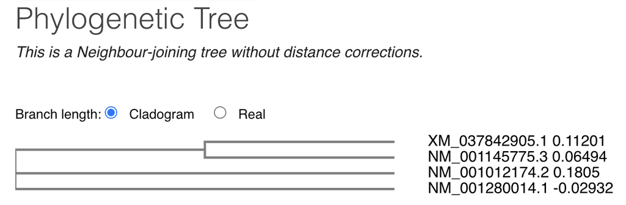

## Analysis of Results

According to the data that was found from our Pairwise Sequence Alignment when comparing the gene FKBP5 sequences among human and animals of interest (Rat, Monkey, and SLoth), the Sloth has the highest similarity score to humans, which makes it the most similar to the gene FKBP5 in human.

Even though plotting the results did not work as planned and the diagram did not show the genetic similarities and relationship among the FKBP5 in human and animals. I was able to combined data that was collected, inserted onto a program from the website https://www.ebi.ac.uk/Tools/msa/clustalo/ and create a phylogenetic clustering. Based on this tree, Sloth (Choloepus didactylus: XM_037842905) and Human (Homo sapiens: NM_001145775.3) are the most closely related compared to Rat (Rattus norvegicus: NM_001012174.2) and Monkey (Saimiri boliviensis: NM_001280014.1).

In conclusion, we found that out of three animals of interests (Rat, Monkey, and Sloth), genetic similarities of the gene FKBP5 in Sloth is the most closely related to Humans. With this infomration and similarities, scientists and researchers can use and do studies on Sloth (Choloepus didactylus) to further their knowledge and understanding on how the gene FKBP5 express in human and how it is related to stress response and cellular processes.